# Surabaya’s Public Health Center Visit Trend Analysis

Pandu Gumelar Pratama

2022-12-22

## Introduction

Public Health Center (or “Puskesmas” in Bahasa), is a health center built by government to ease the health access and fees for Public especially with People that don’t have enough finance to get to private health center. As one of the major city in Indonesia, Surabaya itself have 63 Public Health Center accross the city ([Reference](https://dinkes.surabaya.go.id/portalv2/upt-dinas/puskesmas/))

In this study case we will analyze the trend between new and recurring patients on Surabaya’s Public Health Center From January to November 2022 using the data from Jatim Prov Open Data ([Link](https://opendata.jatimprov.go.id/frontend/dataset/8039/detail_ckan)). The tools that will be used in this study case is RStudio that using R Language as its programming language. The output of this research are the trend starting January 2022 to November 2022 and where is the Public Health Center that have most visitor in average.

## Data Preparation

In this section, we will gather the data provided, checking any inconsistent data if any and merging into single file so we can start analyze the data. As previously stated in Introduction section, the data will be gathered from Jatimprov Open Data website ([Link](https://opendata.jatimprov.go.id/frontend/dataset/8039/detail_ckan)). From the link provided there are 11 links indicated each CSV file are based on month-year the data are gathered.  
Based on the random sampling of the header of all files downloaded (January,April,August and November) there are 8 columns on each file which are

- Periode (Indicating what month period the data are gathered)
- Wilayah (Indicating the region the data are gathered)
- Kecamatan (Indicating the distict the data are gathered)
- Nama Puskesmas (Indicating the name of the Public Health Center)
- Poli (Indicating the region the data are gathered)
- Baru (Indicating the number of new patients visit)
- Lama (Indicating the number of recurring patients visit)
- Total Kunjugan (Indicating the total of the visit combined)

After collecting all the CSV file, the next step are merging the CSV File into single dataframe. To read CSV files we need to import the “readr” and “dplyr” libraries and using lapply to combine all the csv file in the folder.

```r
library(readr)
library(dplyr)
library(lubridate)
df <- list.files(full.names = TRUE) %>%
  lapply(read.csv,sep=";") %>%
  bind_rows
glimpse(df)
```

```
## Rows: 15,469
## Columns: 10
## $ Periode          <chr> "Agustus", "Agustus", "Agustus", "Agustus", "Agustus"…
## $ Wilayah          <chr> "Surabaya Barat", "Surabaya Barat", "Surabaya Barat",…
## $ Kecamatan        <chr> "Asem Rowo", "Asem Rowo", "Asem Rowo", "Asem Rowo", "…
## $ Nama.Puskesmas   <chr> "Puskesmas Asemrowo", "Puskesmas Asemrowo", "Puskesma…
## $ Poli             <chr> "BATRA", "GIGI", "GIZI", "INSTALASI GAWAT DARURAT", "…
## $ Baru             <int> 2, 59, 0, 1, 142, NA, NA, NA, NA, NA, 2, NA, NA, NA, …
## $ Lama             <int> 5, 282, 1, 0, 568, NA, NA, NA, NA, NA, 11, NA, NA, NA…
## $ Total.Kunjungan  <int> 7, 341, 1, 1, 710, 0, 0, 0, 0, 0, 13, 0, 0, 0, 0, 0, …
## $ X..DOCTYPE.html. <chr> NA, NA, NA, NA, NA, NA, NA, NA, NA, NA, NA, NA, NA, N…
## $ X...             <chr> NA, NA, NA, NA, NA, NA, NA, NA, NA, NA, NA, NA, NA, N…
```

```r
df<-subset(df,select=-c(X..DOCTYPE.html.,X...))
glimpse(df)
```

```
## Rows: 15,469
## Columns: 8
## $ Periode         <chr> "Agustus", "Agustus", "Agustus", "Agustus", "Agustus",…
## $ Wilayah         <chr> "Surabaya Barat", "Surabaya Barat", "Surabaya Barat", …
## $ Kecamatan       <chr> "Asem Rowo", "Asem Rowo", "Asem Rowo", "Asem Rowo", "A…
## $ Nama.Puskesmas  <chr> "Puskesmas Asemrowo", "Puskesmas Asemrowo", "Puskesmas…
## $ Poli            <chr> "BATRA", "GIGI", "GIZI", "INSTALASI GAWAT DARURAT", "K…
## $ Baru            <int> 2, 59, 0, 1, 142, NA, NA, NA, NA, NA, 2, NA, NA, NA, N…
## $ Lama            <int> 5, 282, 1, 0, 568, NA, NA, NA, NA, NA, 11, NA, NA, NA,…
## $ Total.Kunjungan <int> 7, 341, 1, 1, 710, 0, 0, 0, 0, 0, 13, 0, 0, 0, 0, 0, 1…
```

## Data Transformation

After two unused columns are removed, we can now progress to the next step, now we want to check how many visits total in all surabaya based on periode/month. To do this we can use group by function combined with summarize and sum functon then arrange in custom order since the not all months are in english, starting from Januari(January) to November

```r
Summarized_Data_Month_Based<-df%>%
  group_by(Periode)%>%
  summarize(New_Visitor=sum(Baru,na.rm = TRUE),Old_Visitor=sum(Lama,na.rm = TRUE),Total_Visit=sum(Total.Kunjungan))%>%
 arrange(match(Periode,c("Januari","Februari","Maret","April","Mei","Juni","Juli","Agustus","September","Oktober","November")))
Summarized_Data_Month_Based
```

```
## # A tibble: 12 × 4
##    Periode   New_Visitor Old_Visitor Total_Visit
##    <chr>           <int>       <int>       <int>
##  1 Januari         24878      159342      184220
##  2 Februari        23243      138711      161954
##  3 Maret           22539      154862      177401
##  4 April           19536      135136      154672
##  5 Mei             21847      148253      170100
##  6 Juni            34554      189270      223824
##  7 Juli            28970      172441      201411
##  8 Agustus         32096      203185      235281
##  9 September       38280      214396      252676
## 10 Oktober        109878      206317      316195
## 11 November        36265      228765      265030
## 12 <NA>                0           0          NA
```

Now, we will delete the NA row using omit NA Function and using ggplot2 library we will create a line graph using the summarized data to see the trend from January to November 2022. In this process we will change to X axis Legend Name to Months and the Y axis legend name to Total Visitor to Total Visitor Trend for easier reading

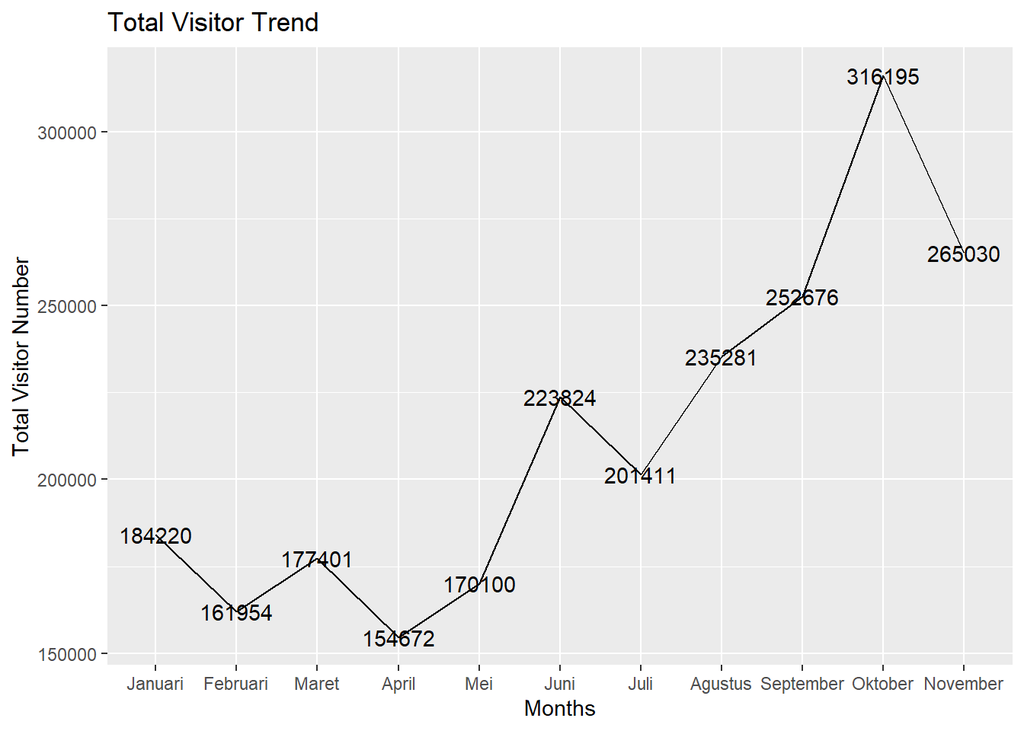

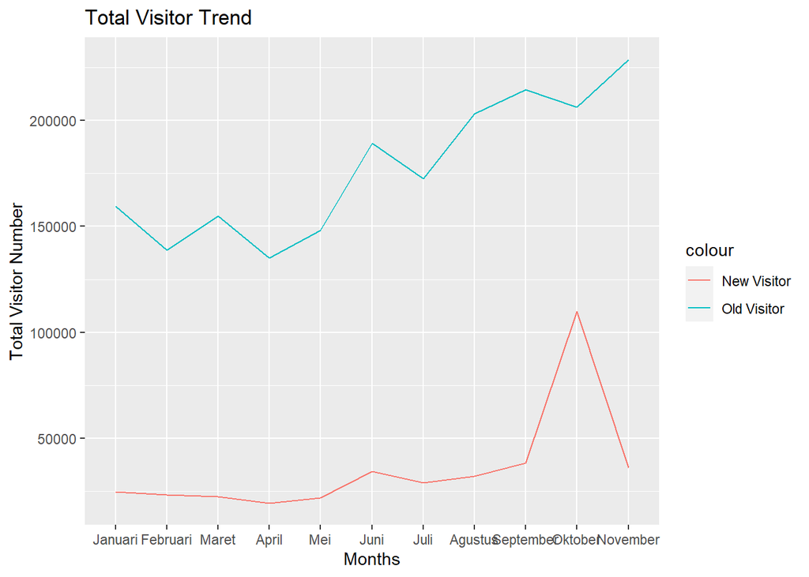

As We can see here, most of the contributor of total visitor are old/recurring visitor. While the new visitor in the lower number, due to the significant contributor in october, it affect the total number of visitor that reached the peak with significant gap comparing to other months. Now we will get to know which public health care visited the most by using the same method but this time with bar graph and we will limit to top 5 most visited public health care using top_n function

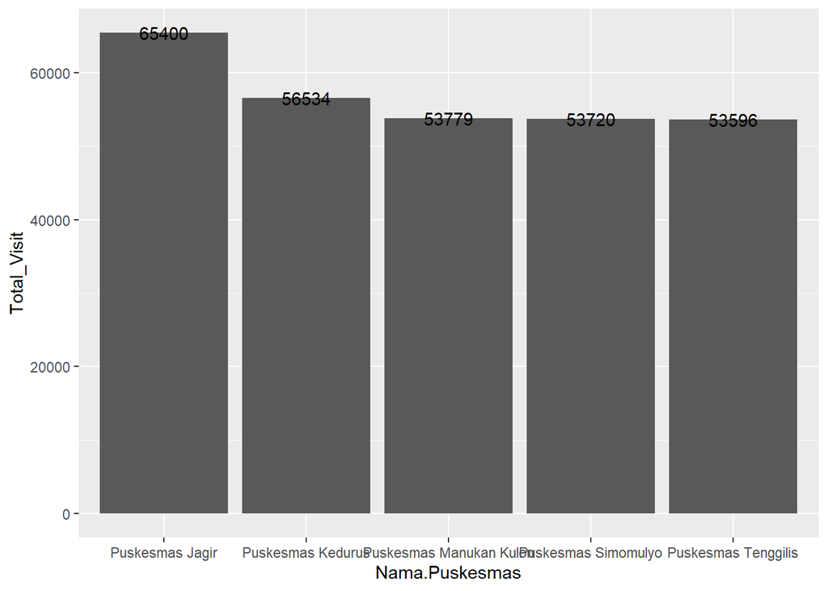

As we can see here from the graph above currently the most visited Public Health Care in Surabaya is Puskesmas Jagir with total of 65400 visitors from January to November 2022